# HIPC ImmuneSignatures Project - Full analysis pipeline using data from ImmuneSpace

## EDITOR’S NOTES:

This markdown file outputs the results of the HIPC ImmuneSignatures Project using the original parameters  
developed by the collaborators. Interested users may re-run the full pipeline with different parameters for  
the raw data pre-processing step, such as gene annotation methods, as well as meta-analysis step, such as  
p-value or FDR cutoffs.

## PRE-PROCESSING PARAMETERS:

- Yale Studies Gene Expression Annotation: original
- Processing of SDY80/CHI-nih from IS rawdata: FALSE
- SDY80/CHI-nih Gene Expression Annotation: original
- SDY80/CHI-nih GE normalization via pipeleine: FALSE

## OUTPUT DIRECTORY:

- /home/ehenrich/R/ImmSigPkg/R/ImmSig_Analysis

### NOTES:

1. Gene expression annotation methods:
- original = using the original pre-processed GE table from HIPC collaborators to generate a hash of Probe IDs as keys and Gene Symbols as values. For the Yale Studies, this method means that the annotation is based on the GE table provided from the Illumina sequencing machine at the time of the run. For SDY80/CHI-nih, the information is from the Affymetrix annotation done at the time.
- library = the use of a bioconductor library. For Yale Studies, this was illuminahumanv4.db. For SDY80, it was hugene10sttranscriptcluster.db.
- manifest = Uses the manifest available from the Illumina website which consists of all historic probeIDs. In the case of the Yale Studies, this generates complete mapping, whereas the original table has only partial mapping and the library even less.
2. SDY80 / CHI-nih normalization
- In the original code used to develop the manuscript, The study’s rawdata from the GEO database has been log2 transformed, but is not normalized in the same was as the discovery studies (i.e. preprocessCore::normalize.quantiles). Therefore sdy80.norm is FALSE by default. However, the user may set it to TRUE and use the same normalization procedure as the other studies.

## YOUNG COHORT META-ANALYSIS RESULTS

```
##
## DISCOVERY COHORT RESULTS
##
##
## |                                                                         |    Pvalue|       FDR| pathwayActivity|
## |:------------------------------------------------------------------------|---------:|---------:|---------------:|
## |targets of FOSL1/2 (M0)                                                  | 0.1895983| 0.4380787|       0.0619409|
## |integrin cell surface interactions (I) (M1.0)                            | 0.9189256| 0.9766976|       0.0095827|
## |integrin cell surface interactions (II) (M1.1)                           | 0.7667853| 0.9148542|       0.0066823|
## |extracellular matrix (I) (M2.0)                                          | 0.8507550| 0.9602405|       0.0050267|
## |extracellular matrix (II) (M2.1)                                         | 0.1878768| 0.4380787|       0.0648412|
## |extracellular matrix (III) (M2.2)                                        | 0.4573547| 0.7137013|      -0.0072632|
## |regulation of signal transduction (M3)                                   | 0.0556479| 0.2917301|       0.1017809|
## |cell cycle and transcription (M4.0)                                      | 0.4544036| 0.7137013|       0.0838294|
## |cell cycle (I) (M4.1)                                                    | 0.4255661| 0.7032927|      -0.0169726|
## |PLK1 signaling events (M4.2)                                             | 0.6945328| 0.8689057|      -0.0047206|
## |myeloid cell enriched receptors and transporters (M4.3)                  | 0.0476401| 0.2687709|       0.1851128|
## |mitotic cell cycle - DNA replication (M4.4)                              | 0.0380340| 0.2564171|      -0.0370997|
## |mitotic cell cycle in stimulated CD4 T cells (M4.5)                      | 0.1408148| 0.3866512|      -0.0372518|
## |cell division in stimulated CD4 T cells (M4.6)                           | 0.6756511| 0.8563197|      -0.0042045|
## |mitotic cell cycle (M4.7)                                                | 0.6677225| 0.8563197|      -0.0040624|
## |cell division - E2F transcription network (M4.8)                         | 0.0468148| 0.2687709|      -0.0385888|
## |mitotic cell cycle in stimulated CD4 T cells (M4.9)                      | 0.3396210| 0.6016671|      -0.0142473|
## |cell cycle (II) (M4.10)                                                  | 0.5788104| 0.8108033|      -0.0099662|
## |mitotic cell cycle in stimulated CD4 T cells (M4.11)                     | 0.2365309| 0.4959981|      -0.0227350|
## |C-MYC transcriptional network (M4.12)                                    | 0.3113156| 0.5854087|      -0.0295777|
## |cell junction (GO) (M4.13)                                               | 0.0149944| 0.2509491|       0.2115385|
## |Rho GTPase cycle (M4.14)                                                 | 0.9214624| 0.9766976|       0.0042659|
## |enriched in monocytes (I) (M4.15)                                        | 0.1001294| 0.3583421|       0.1445047|
## |regulation of antigen presentation and immune response (M5.0)            | 0.2826555| 0.5463620|       0.0442623|
## |T cell activation and signaling (M5.1)                                   | 0.0905575| 0.3443176|      -0.0761862|
## |mitotic cell division (M6)                                               | 0.3217211| 0.5952701|      -0.0151831|
## |enriched in T cells (I) (M7.0)                                           | 0.1536144| 0.3966462|      -0.0822906|
## |T cell activation (I) (M7.1)                                             | 0.1341763| 0.3786431|      -0.0764629|
## |enriched in NK cells (I) (M7.2)                                          | 0.4901892| 0.7248097|      -0.0666938|
## |T cell activation (II) (M7.3)                                            | 0.1681405| 0.4161515|      -0.0555768|
## |T cell activation (III) (M7.4)                                           | 0.0337872| 0.2509491|      -0.1098889|
## |E2F transcription factor network (M8)                                    | 0.5373605| 0.7619948|      -0.0102388|
## |B cell development (M9)                                                  | 0.0601176| 0.3104581|       0.0615066|
## |E2F1 targets (Q3) (M10.0)                                                | 0.0064060| 0.2285650|      -0.0491829|
```

[output cut: 297 more lines]

```
## |TBA (M248)                                                               | 0.2589575| 0.5209262|       0.0405254|
## |TBA (M249)                                                               | 0.0359874| 0.2509491|      -0.0678140|
## |spliceosome (M250)                                                       | 0.9172337| 0.9766976|       0.0055845|
## |T cell surface signature (S0)                                            | 0.1111604| 0.3624214|      -0.0599560|
## |NK cell surface signature (S1)                                           | 0.4672925| 0.7149502|      -0.0540034|
## |B cell surface signature (S2)                                            | 0.9488592| 0.9796496|       0.0033407|
## |Plasma cell surface signature (S3)                                       | 0.1756015| 0.4161515|       0.0171525|
## |Monocyte surface signature (S4)                                          | 0.2122809| 0.4582287|       0.1225716|
## |DC surface signature (S5)                                                | 0.4563099| 0.7137013|       0.0197908|
## |CD4 T cell surface signature Th1-stimulated (S6)                         | 0.4399521| 0.7137013|      -0.0228820|
## |CD4 T cell surface signature Th2-stimulated (S7)                         | 0.1529782| 0.3966462|      -0.0501766|
## |Naive B cell surface signature (S8)                                      | 0.8337773| 0.9552558|       0.0011136|
## |Memory B cell surface signature (S9)                                     | 0.7241623| 0.8822541|      -0.0010114|
## |Resting dendritic cell surface signature (S10)                           | 0.1228775| 0.3639456|       0.0473541|
## |Activated (LPS) dendritic cell surface signature (S11)                   | 0.2046302| 0.4482260|       0.0432690|
```

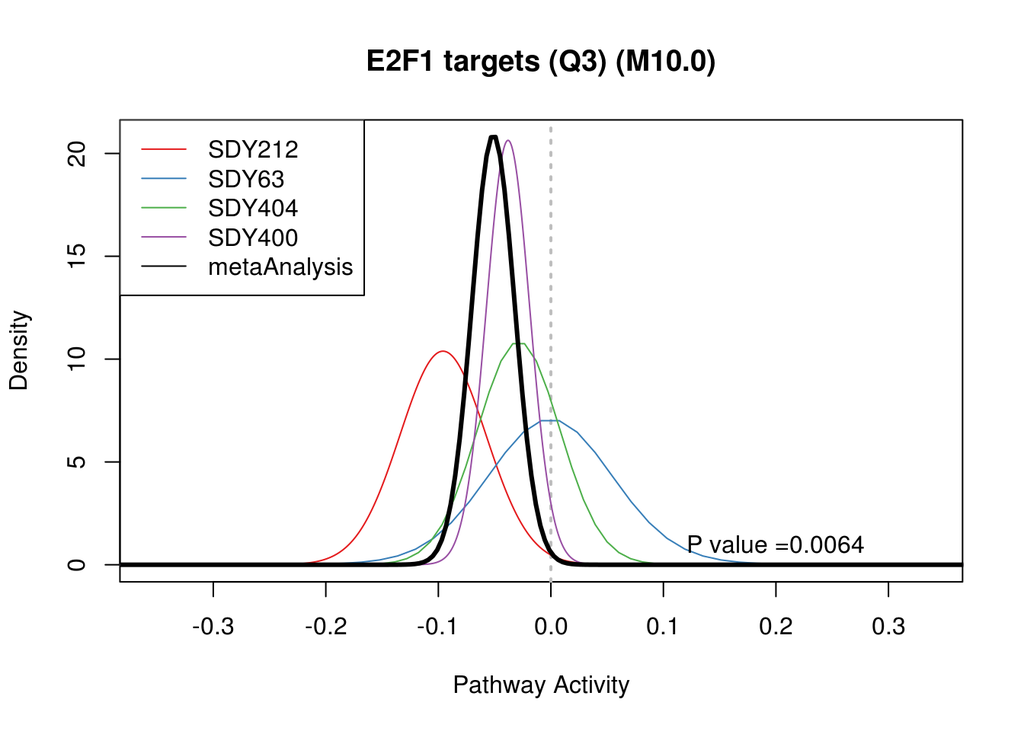

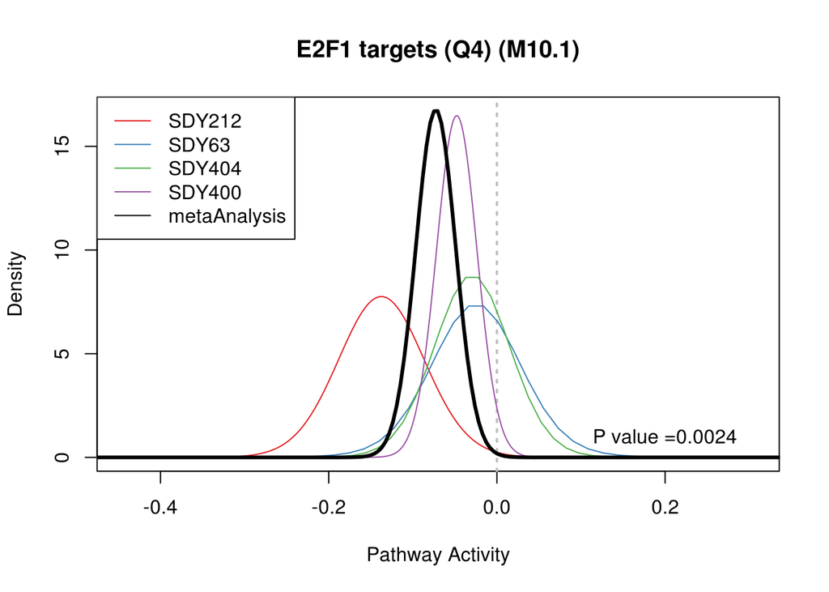

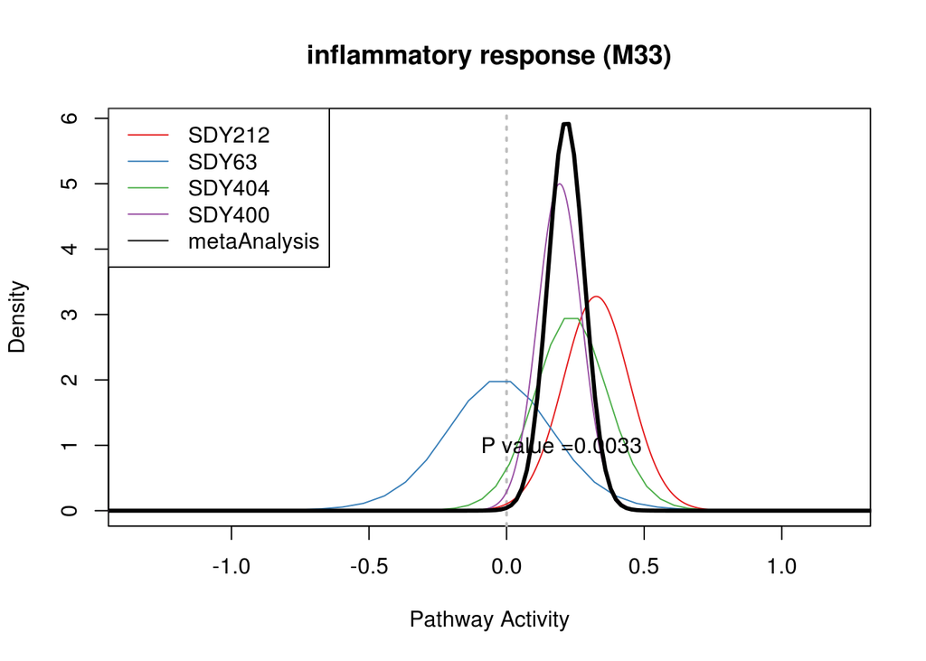

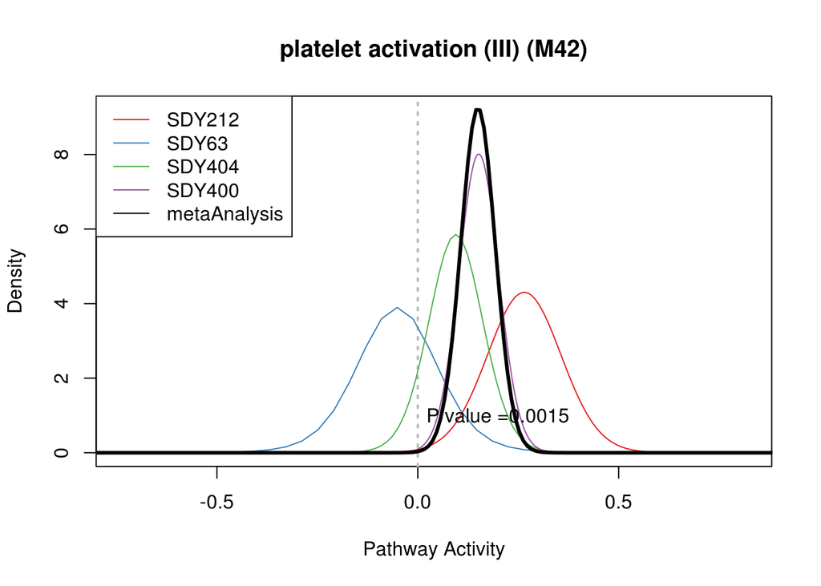

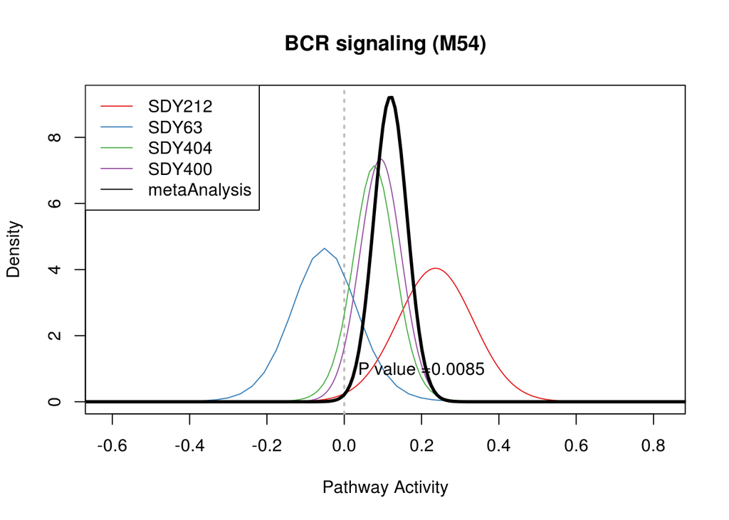

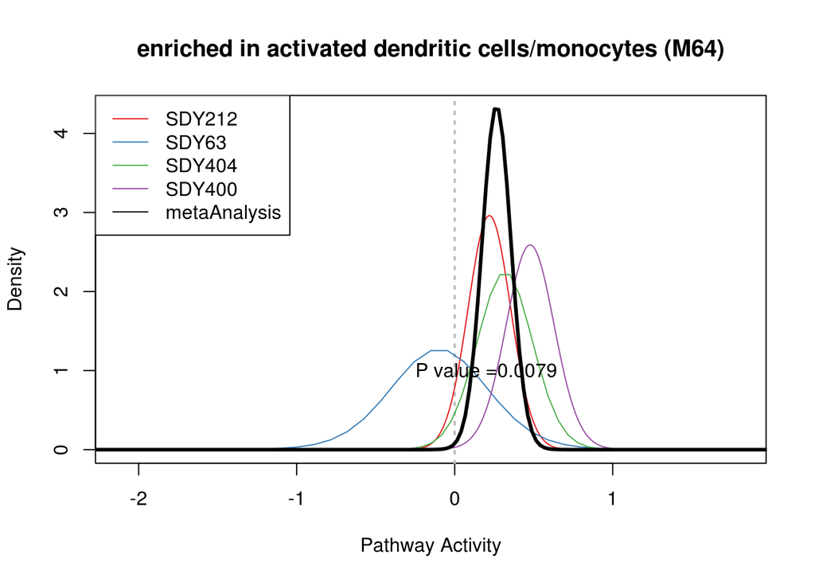

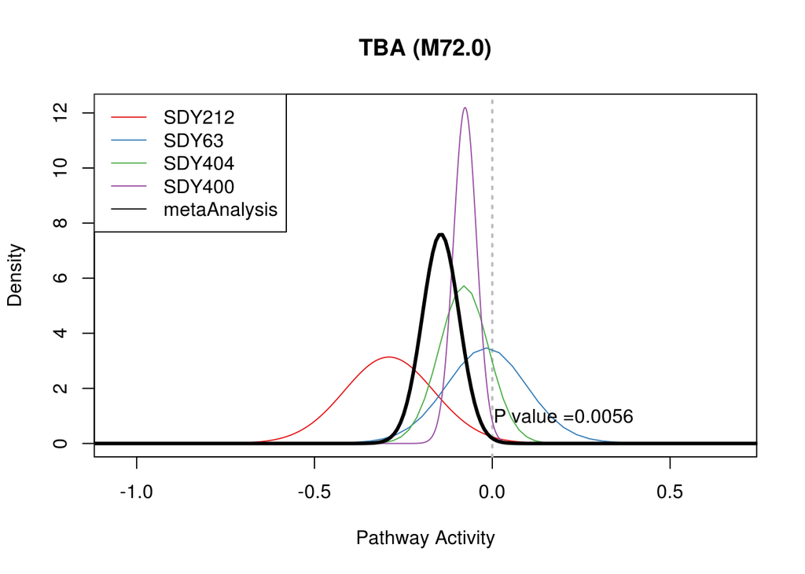

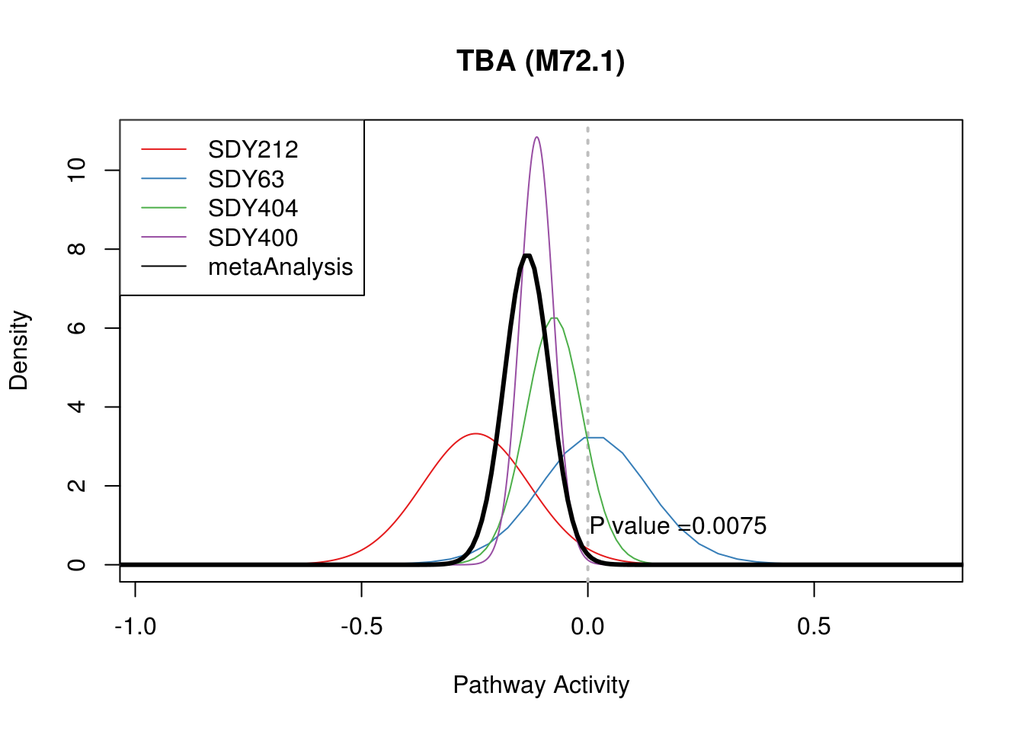

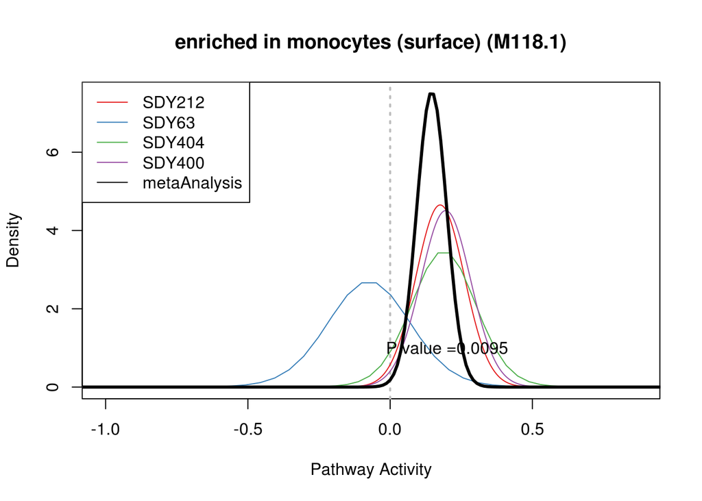

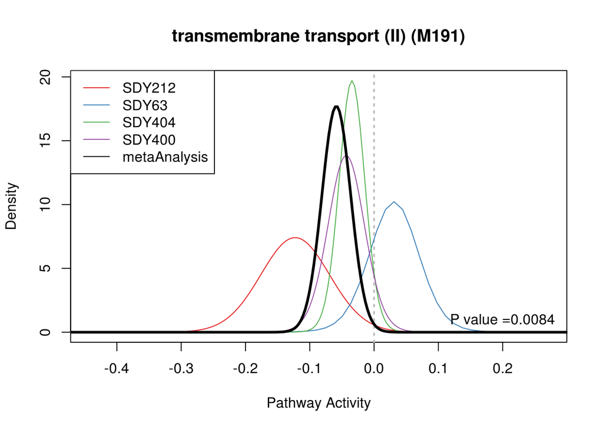

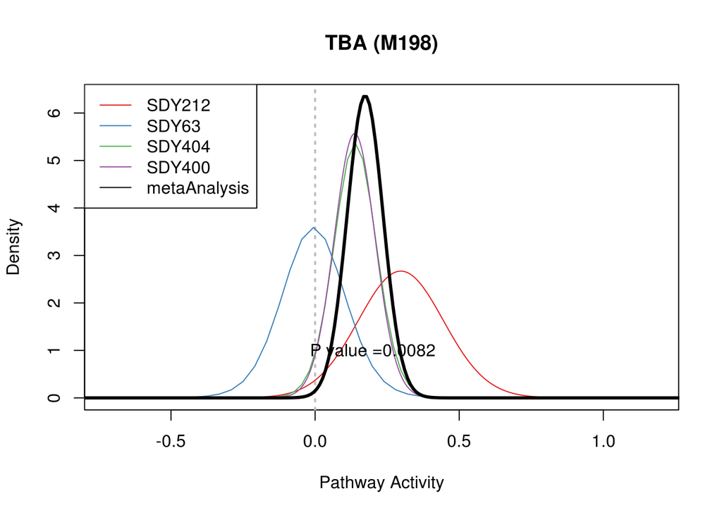

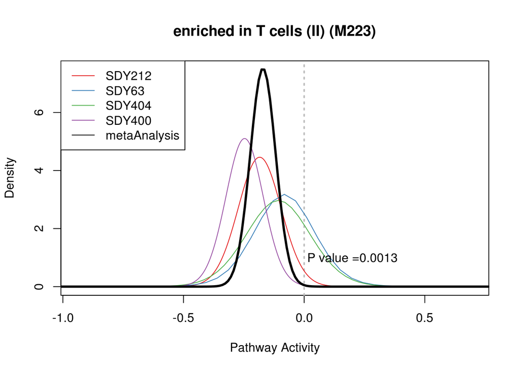

```
##
##
##
##
##
##
##
##
##
##
##
## VALIDATION STUDY RESULTS
##
##
## |                                                      |    pvalue|    qvalue| pathway.activity.selected|
## |:-----------------------------------------------------|---------:|---------:|-------------------------:|
## |E2F1 targets (Q3) (M10.0)                             | 0.9078559| 0.9078559|                 0.0049110|
## |E2F1 targets (Q4) (M10.1)                             | 0.4859154| 0.6478871|                 0.0353041|
## |inflammatory response (M33)                           | 0.0217602| 0.0652806|                 0.1932186|
## |platelet activation (III) (M42)                       | 0.0076051| 0.0456305|                 0.1398326|
## |BCR signaling (M54)                                   | 0.0001683| 0.0020195|                 0.1733235|
## |enriched in activated dendritic cells/monocytes (M64) | 0.6219959| 0.6785410|                 0.0656800|
## |TBA (M72.0)                                           | 0.4342191| 0.6478871|                 0.0541021|
## |TBA (M72.1)                                           | 0.2189007| 0.3752583|                 0.0733872|
## |enriched in monocytes (surface) (M118.1)              | 0.0116727| 0.0466907|                 0.2427641|
## |transmembrane transport (II) (M191)                   | 0.0823835| 0.1977205|                -0.0378163|
## |TBA (M198)                                            | 0.1468223| 0.2936445|                 0.1013827|
## |enriched in T cells (II) (M223)                       | 0.5768895| 0.6785410|                -0.0569108|
```

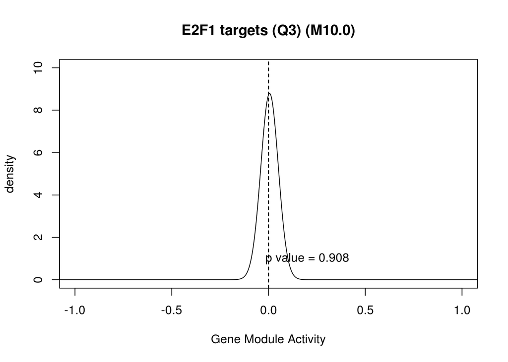

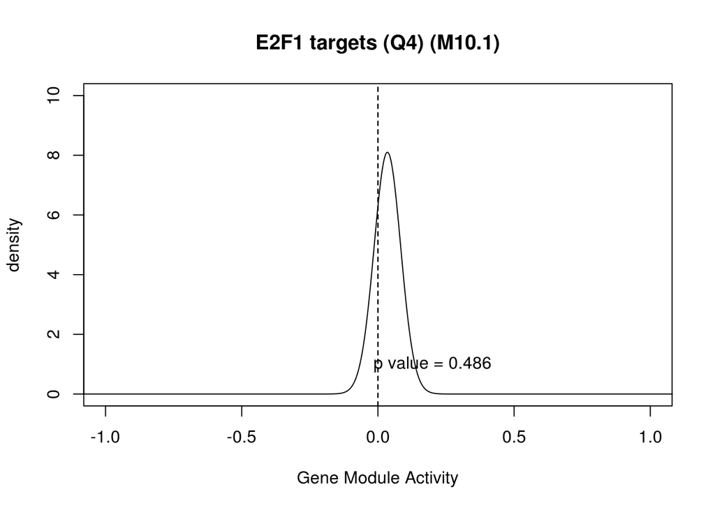

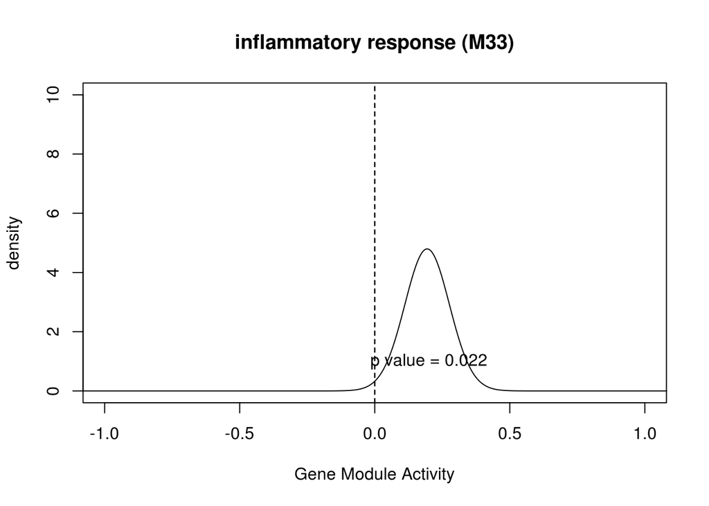

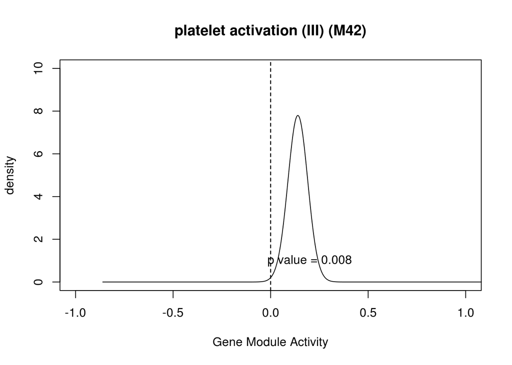

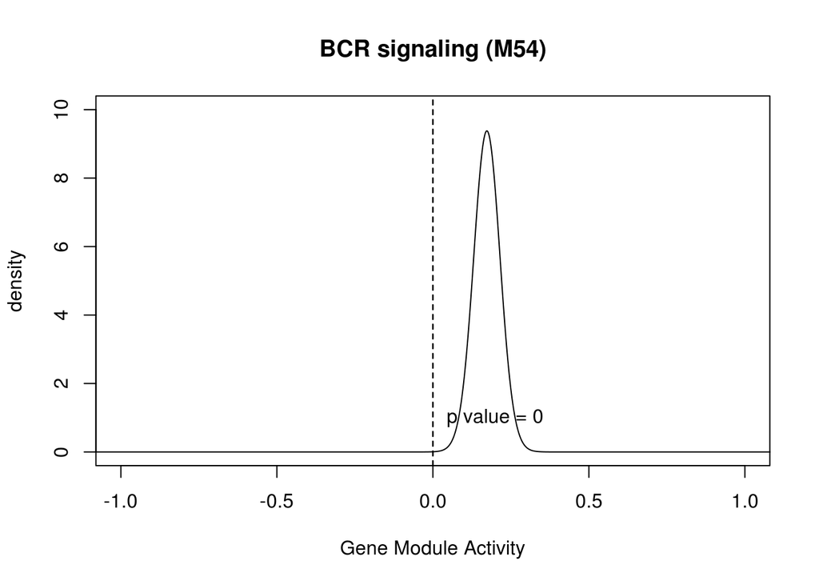

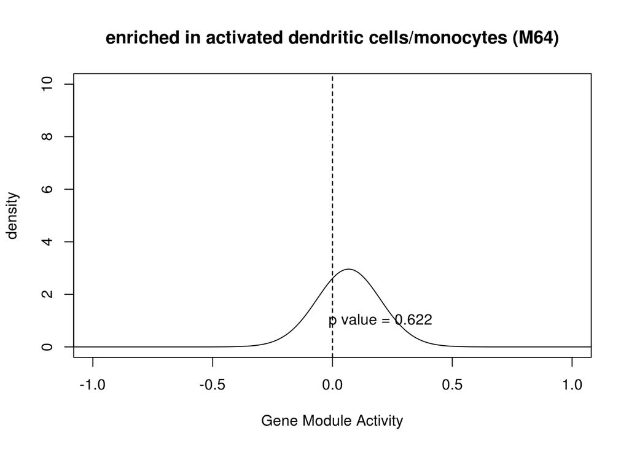

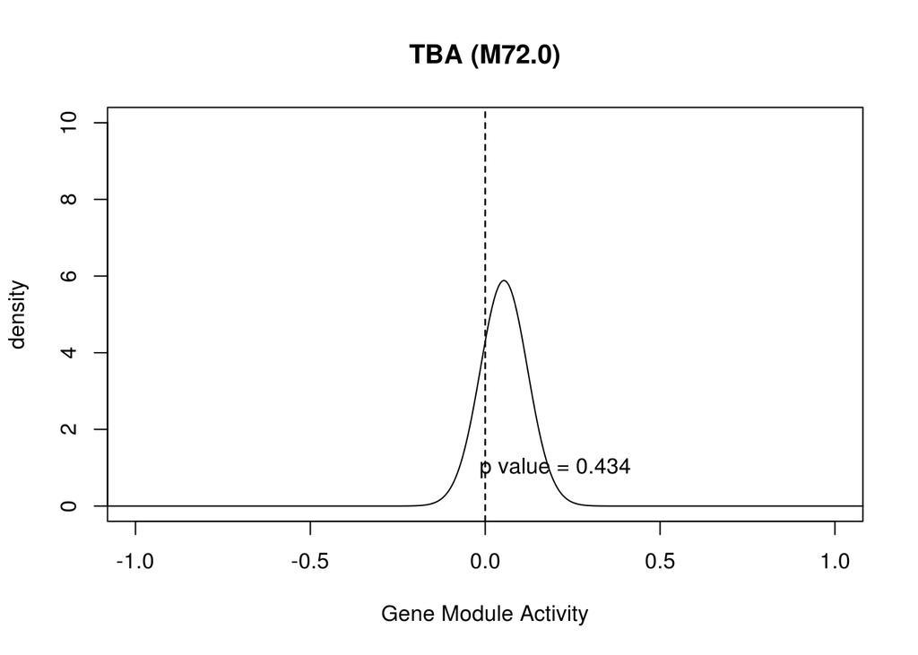

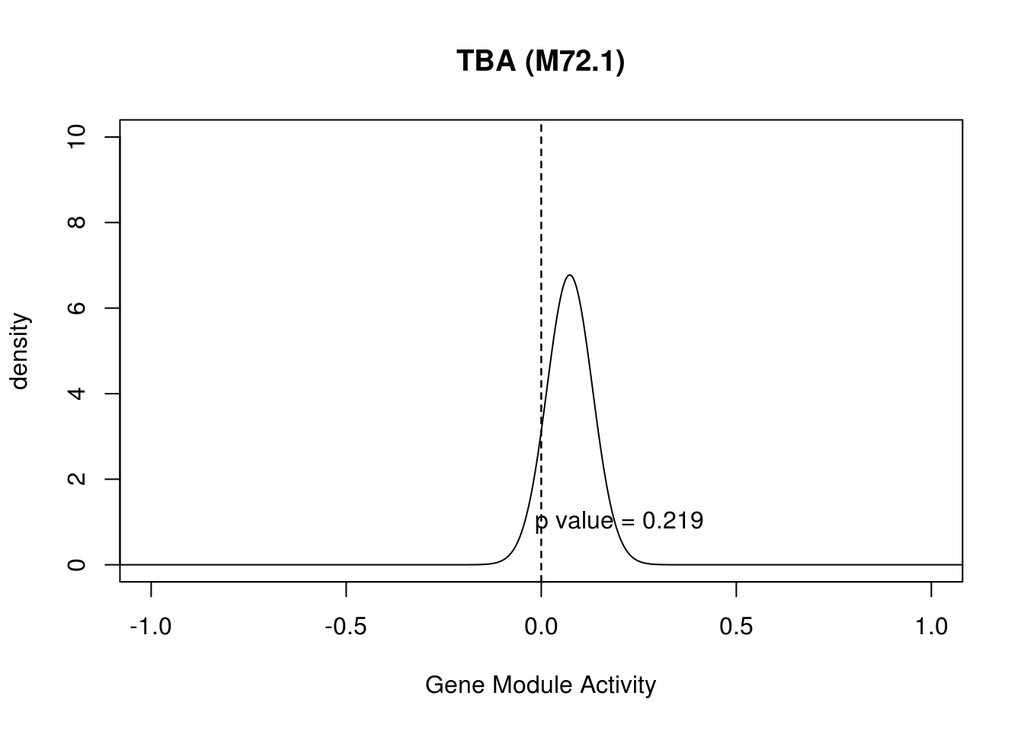

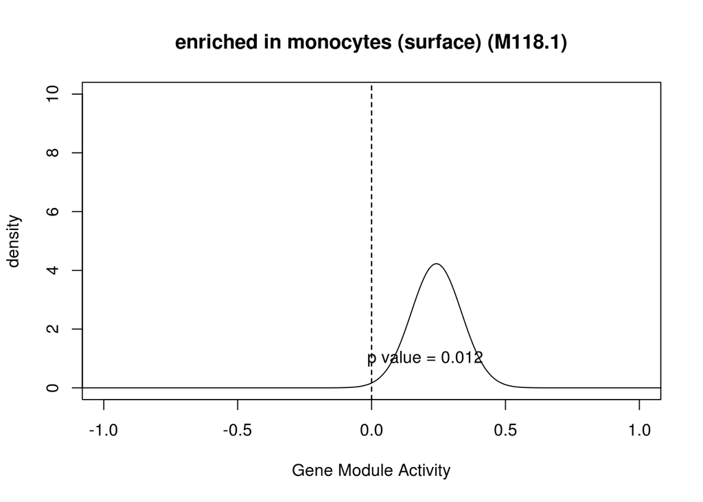

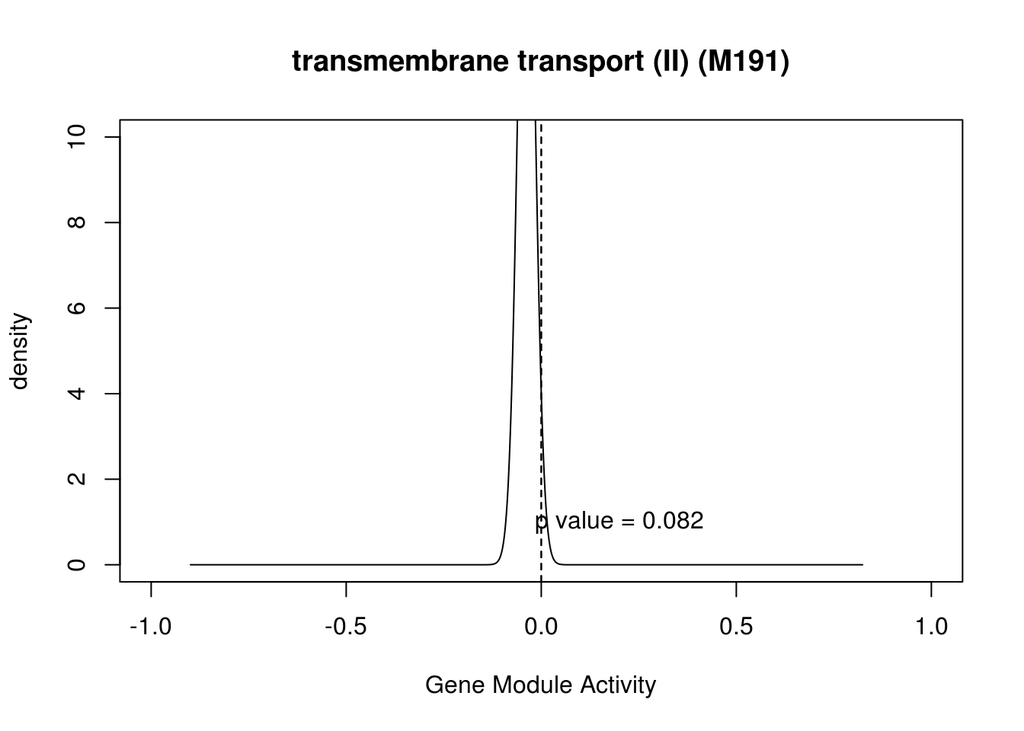

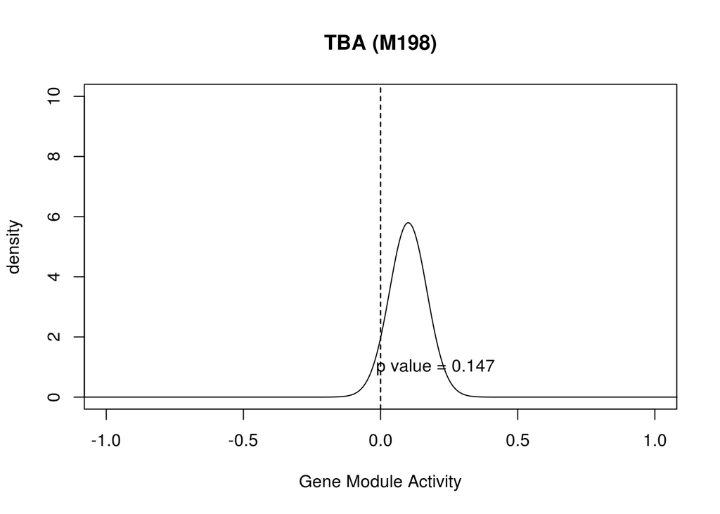

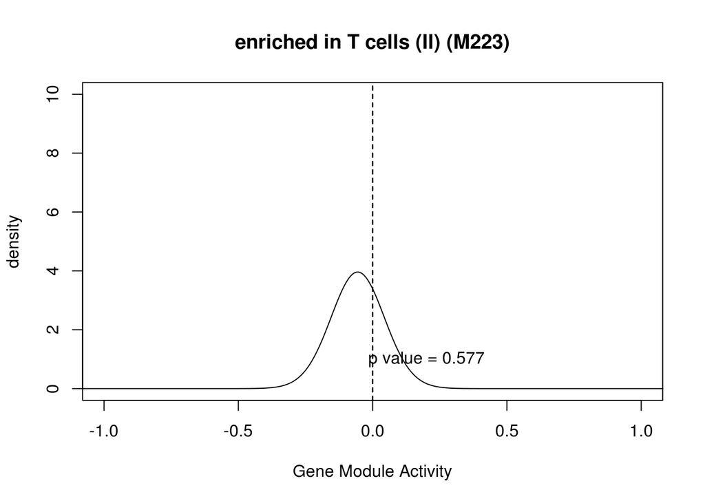

## OLD COHORT META-ANALYSIS RESULTS

```
##
## DISCOVERY COHORT RESULTS
##
##
## |                                                                         |    Pvalue|       FDR| pathwayActivity|
## |:------------------------------------------------------------------------|---------:|---------:|---------------:|
## |targets of FOSL1/2 (M0)                                                  | 0.7102321| 0.8621071|       0.0168883|
## |integrin cell surface interactions (I) (M1.0)                            | 0.3931177| 0.6906927|       0.0205386|
## |integrin cell surface interactions (II) (M1.1)                           | 0.6224013| 0.8478380|       0.0139536|
## |extracellular matrix (I) (M2.0)                                          | 0.1657496| 0.5869574|      -0.0146596|
## |extracellular matrix (II) (M2.1)                                         | 0.5365892| 0.8002581|      -0.0314797|
## |extracellular matrix (III) (M2.2)                                        | 0.1489535| 0.5869574|      -0.0139574|
## |regulation of signal transduction (M3)                                   | 0.0829397| 0.5365035|      -0.0486665|
## |cell cycle and transcription (M4.0)                                      | 0.1175608| 0.5365035|      -0.0421067|
## |cell cycle (I) (M4.1)                                                    | 0.1042842| 0.5365035|       0.0203865|
## |PLK1 signaling events (M4.2)                                             | 0.1745381| 0.5869574|       0.0206906|
## |myeloid cell enriched receptors and transporters (M4.3)                  | 0.0211294| 0.4889153|      -0.1228458|
## |mitotic cell cycle - DNA replication (M4.4)                              | 0.1197969| 0.5365035|       0.0300210|
## |mitotic cell cycle in stimulated CD4 T cells (M4.5)                      | 0.6054930| 0.8443515|       0.0181554|
## |cell division in stimulated CD4 T cells (M4.6)                           | 0.0838668| 0.5365035|       0.0305810|
## |mitotic cell cycle (M4.7)                                                | 0.2458812| 0.6025629|       0.0131628|
## |cell division - E2F transcription network (M4.8)                         | 0.2399813| 0.6025629|       0.0258758|
## |mitotic cell cycle in stimulated CD4 T cells (M4.9)                      | 0.2583340| 0.6025629|       0.0206689|
## |cell cycle (II) (M4.10)                                                  | 0.6896884| 0.8571118|       0.0087691|
## |mitotic cell cycle in stimulated CD4 T cells (M4.11)                     | 0.2649474| 0.6025629|       0.0163426|
## |C-MYC transcriptional network (M4.12)                                    | 0.6985709| 0.8571118|       0.0078182|
## |cell junction (GO) (M4.13)                                               | 0.0258011| 0.4889153|      -0.1396319|
## |Rho GTPase cycle (M4.14)                                                 | 0.3972481| 0.6906927|       0.0235342|
## |enriched in monocytes (I) (M4.15)                                        | 0.0477112| 0.4889153|      -0.0886680|
## |regulation of antigen presentation and immune response (M5.0)            | 0.0366573| 0.4889153|      -0.0412542|
## |T cell activation and signaling (M5.1)                                   | 0.2410434| 0.6025629|      -0.0504772|
## |mitotic cell division (M6)                                               | 0.0519586| 0.4889153|       0.0255783|
## |enriched in T cells (I) (M7.0)                                           | 0.7856108| 0.8825368|       0.0197982|
## |T cell activation (I) (M7.1)                                             | 0.5318670| 0.7966493|       0.0339724|
## |enriched in NK cells (I) (M7.2)                                          | 0.8387849| 0.9234663|       0.0296128|
## |T cell activation (II) (M7.3)                                            | 0.8236196| 0.9104549|      -0.0035237|
## |T cell activation (III) (M7.4)                                           | 0.1723976| 0.5869574|       0.1139785|
## |E2F transcription factor network (M8)                                    | 0.0455103| 0.4889153|       0.0364330|
## |B cell development (M9)                                                  | 0.2558776| 0.6025629|      -0.0246017|
## |E2F1 targets (Q3) (M10.0)                                                | 0.0976265| 0.5365035|       0.0327560|
```

[output cut: 297 more lines]

```
## |TBA (M248)                                                               | 0.1415369| 0.5761383|      -0.0505131|
## |TBA (M249)                                                               | 0.0528199| 0.4889153|       0.0800738|
## |spliceosome (M250)                                                       | 0.6122030| 0.8443515|      -0.0170028|
## |T cell surface signature (S0)                                            | 0.5005568| 0.7706528|       0.0318474|
## |NK cell surface signature (S1)                                           | 0.5459478| 0.8070025|       0.0350616|
## |B cell surface signature (S2)                                            | 0.4116107| 0.7015631|       0.0118050|
## |Plasma cell surface signature (S3)                                       | 0.0103442| 0.4889153|      -0.0301093|
## |Monocyte surface signature (S4)                                          | 0.0277445| 0.4889153|      -0.0968945|
## |DC surface signature (S5)                                                | 0.4865699| 0.7687359|      -0.0095235|
## |CD4 T cell surface signature Th1-stimulated (S6)                         | 0.5832398| 0.8236774|       0.0368418|
## |CD4 T cell surface signature Th2-stimulated (S7)                         | 0.3234197| 0.6544048|       0.0527431|
## |Naive B cell surface signature (S8)                                      | 0.5941820| 0.8323359|       0.0063059|
## |Memory B cell surface signature (S9)                                     | 0.3688924| 0.6906927|       0.0130910|
## |Resting dendritic cell surface signature (S10)                           | 0.0429615| 0.4889153|      -0.0416644|
## |Activated (LPS) dendritic cell surface signature (S11)                   | 0.9002148| 0.9570264|       0.0035472|
```

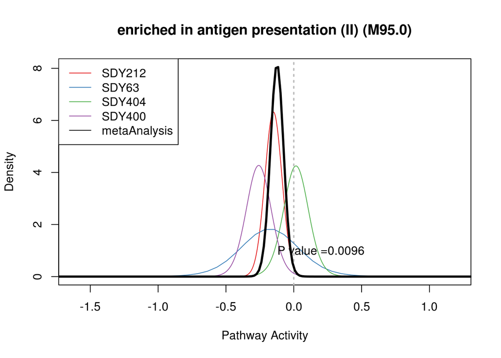

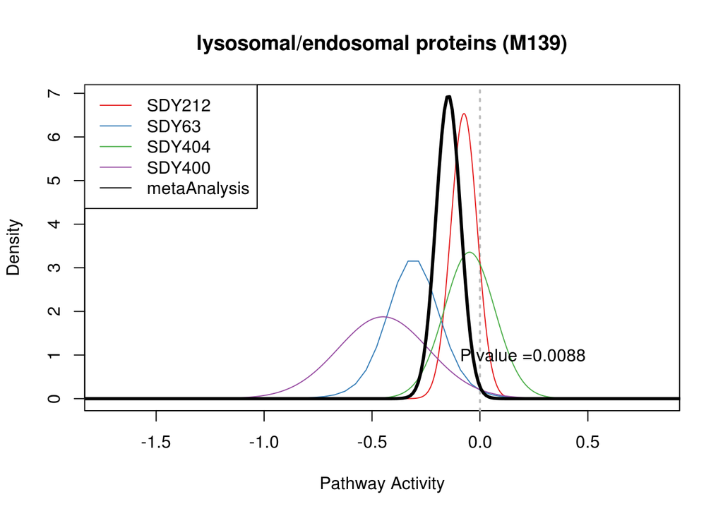

```
##
##
##
##
##
##
##
##
##
##
##
## VALIDATION STUDY RESULTS
##
##
## |                                              |    pvalue|    qvalue| pathway.activity.selected|
## |:---------------------------------------------|---------:|---------:|-------------------------:|
## |enriched in antigen presentation (II) (M95.0) | 0.9582063| 0.9582063|                 0.0034313|
## |lysosomal/endosomal proteins (M139)           | 0.9500689| 0.9582063|                 0.0095541|
```

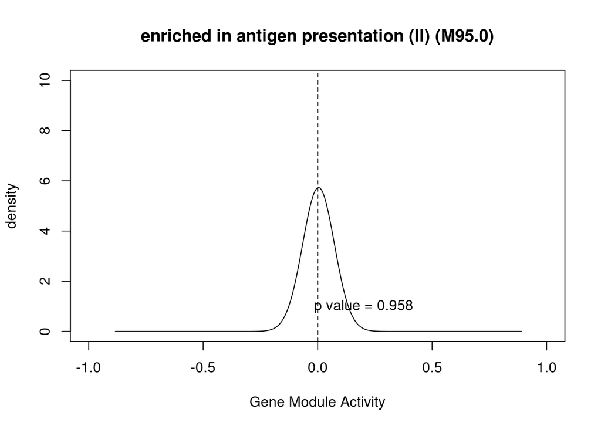

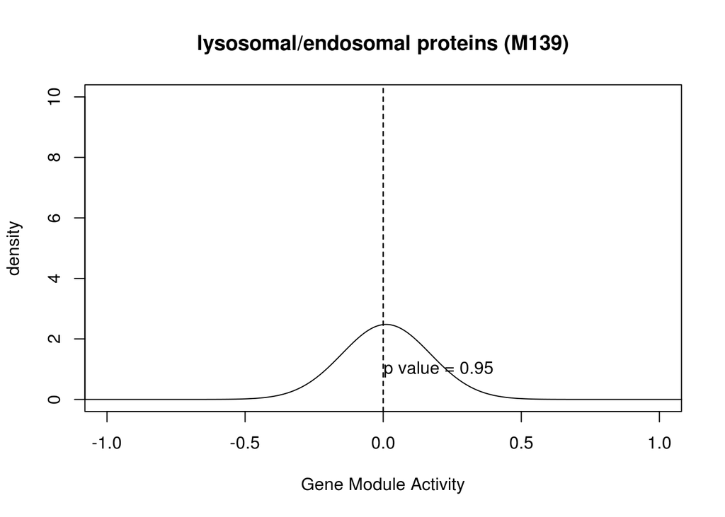

## META-ANALYSIS PARAMETERS:

- FDR.cutoff = 0.5
- pvalue.cutoff = 0.01
- endPoint = fc_res_max_d30
- adjusted = FALSE
- baselineOnly = TRUE
- indiv_rds = FALSE
- geneSetDB = BTM_for_GSEA_20131008.gmt

## PARAMETERS DEFINITION:

- FDR.cutoff = Cut off point for q-values, in code ‘combined.q <- p.adjust(combined.p, method=“BH”)’
- pvalue.cutoff = Cut off point for p-values when selecting gene pathways as ‘significant’ from the discovery studies. In code, ‘combined.p <- pdf.pval(combinePDFs(quSageObjList, n.points = 2^14))’
- endPoint = the HAI column used for labeling “responders” and “non-responders” to a vaccine. The user has the option of fc_res_max_d30 or fc_res_max_d20, which select either the 30% / 70% points for discretization or 20% / 80% respectively.
- adjusted = If TRUE, selects the age-adjusted gene expression values for use in calculations.
- baselineOnly = If TRUE, uses only day zero gene expression values in calculations.
- indiv_rds = If TRUE, outputs the rds files for the individual studies as part of the output
- geneSetDB = The file used for gene set definition.